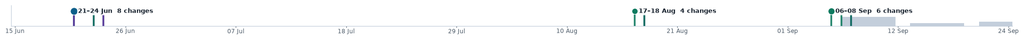

# Swing Trader · Control Centre

The cheat sheet, with the panels made operable. Three columns: choose the inputs, fit and tune the model, read the result.

LOCAL, PAPER ONLY **$102,206** *$2,206* · open 50 *$4,481* · closed 58 *-$2,265* · cash $10,246 seamusrobertmurphy/swing-trader · nothing here can place an order

A1Data➞ A2Indicators➞ B1Variables➞ B2Training➞ C1Scoreboard➞ C2Ledger

## A1Datamarket, basket, filter, ranking, label

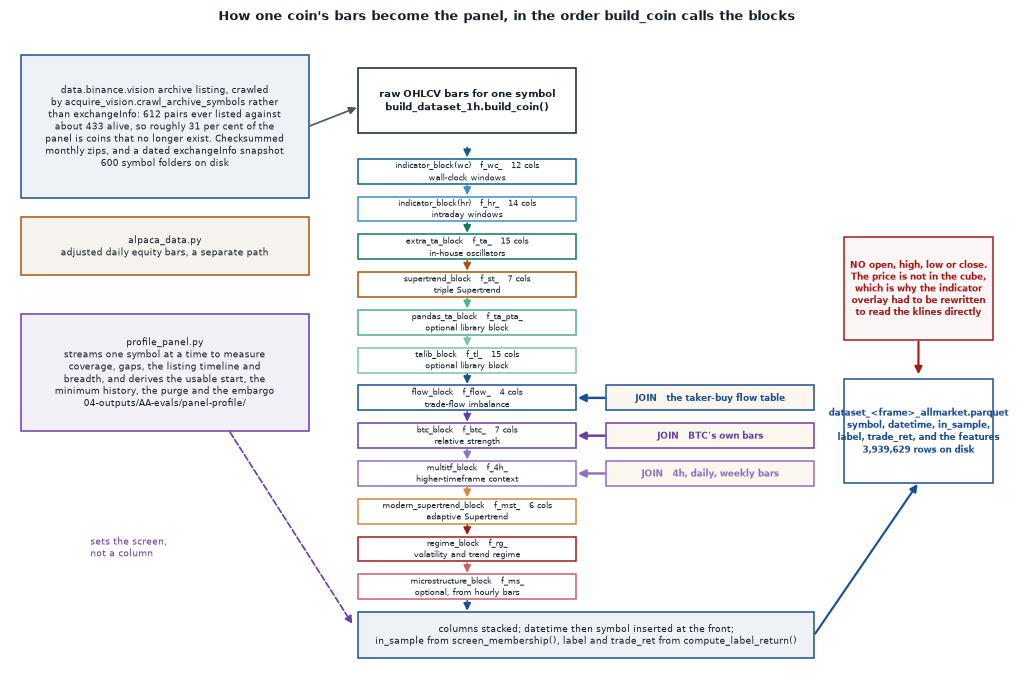

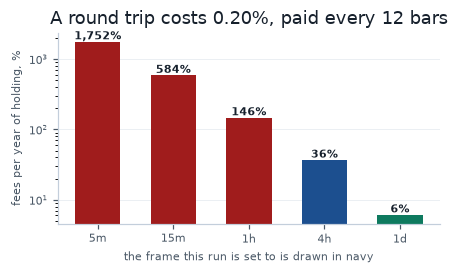

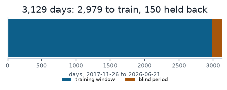

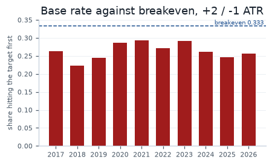

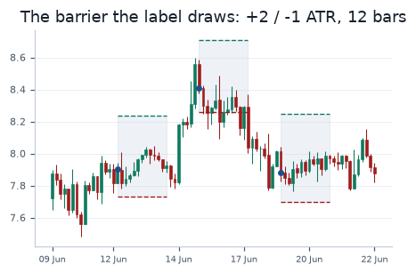

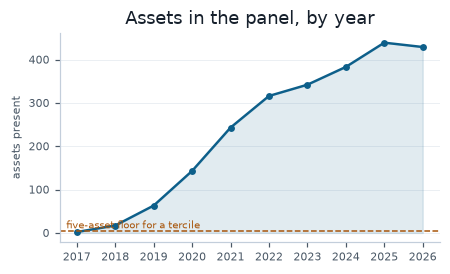

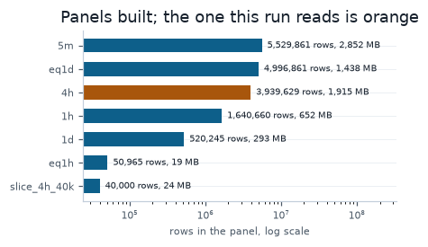

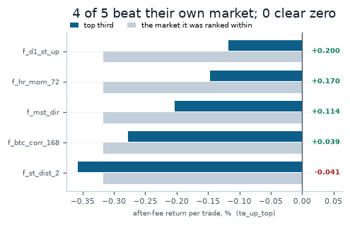

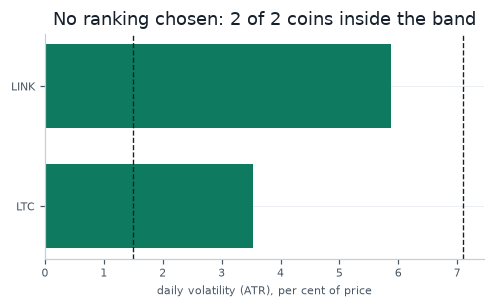

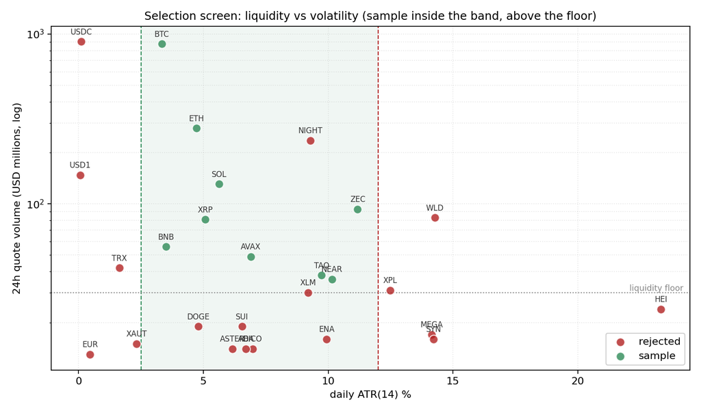

3/10

Training window against blind period

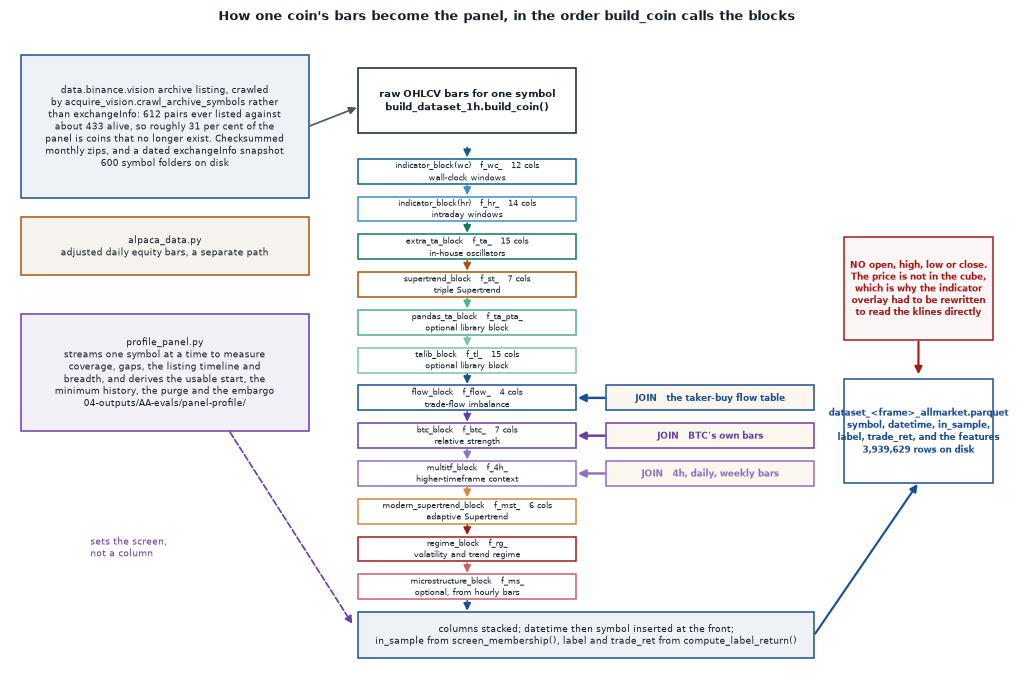

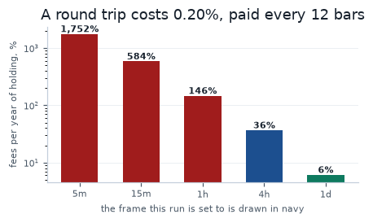

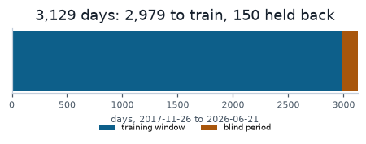

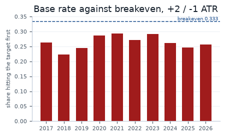

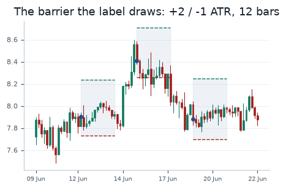

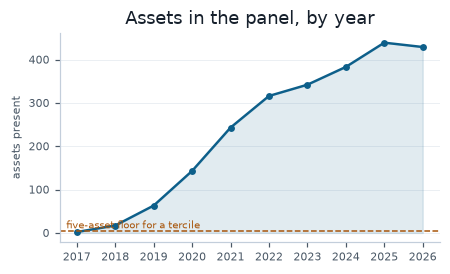

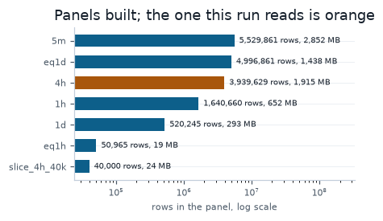

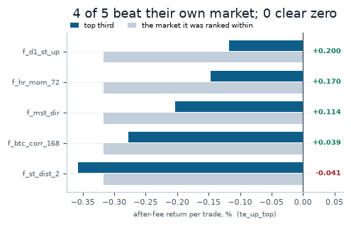

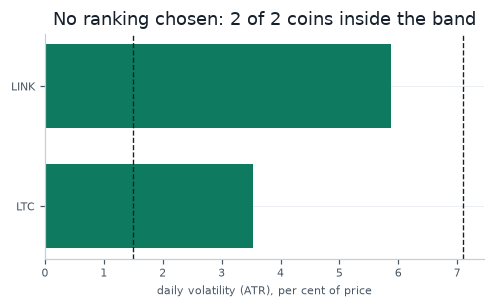

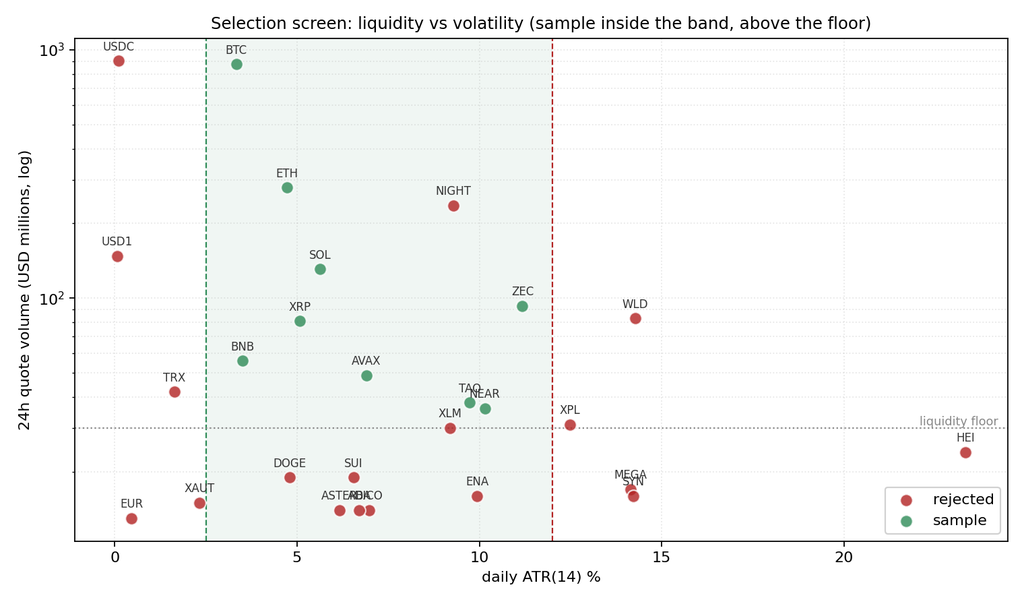

2/10

What a round trip costs, by timeframe

Market, timeframe, symbols, screen.

## A2Indicatorsfeatures, macd, averages, fibonacci, confluence

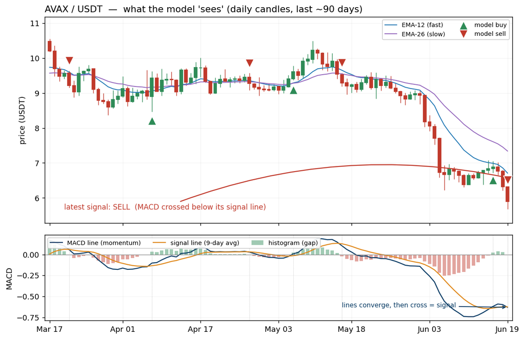

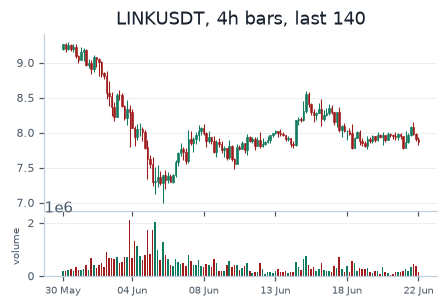

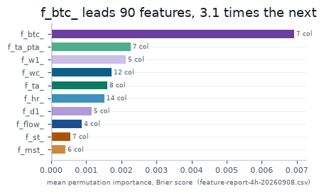

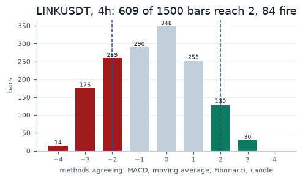

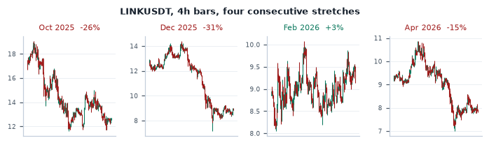

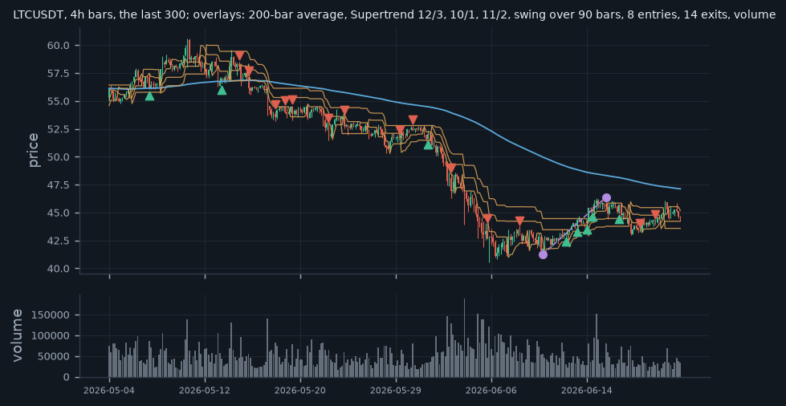

4/22

Columns per feature family

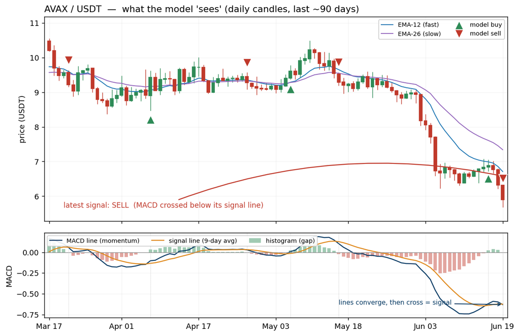

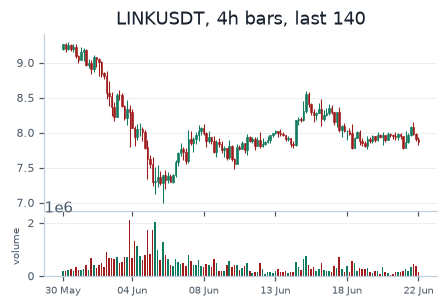

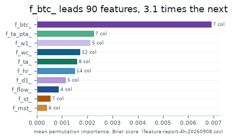

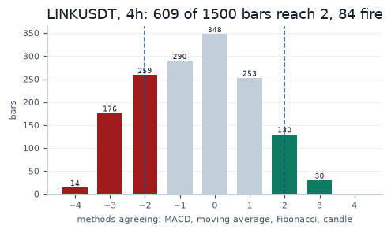

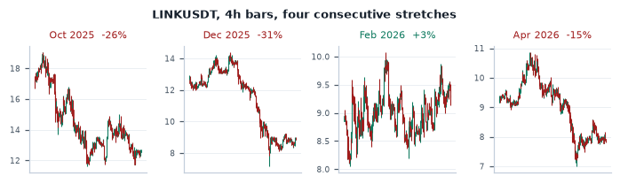

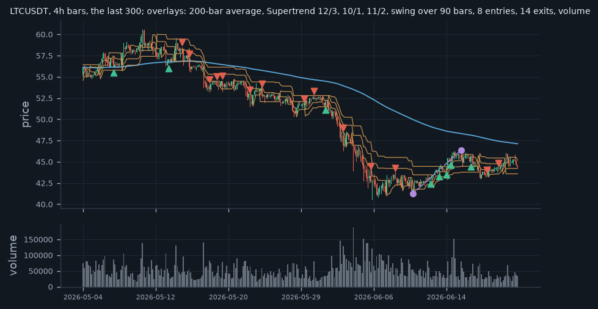

5/22

Which families carry weight

Feature families and indicator engines.

08 Sep 2026 8 charts · settings

## B1Variablesscreen

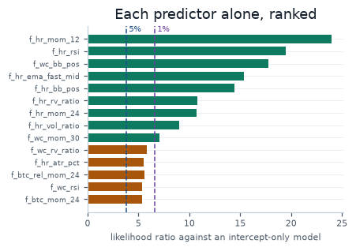

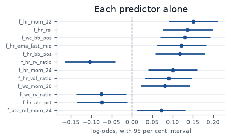

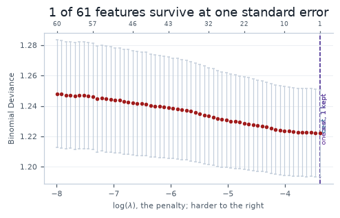

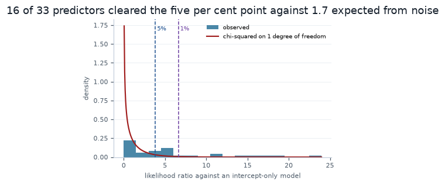

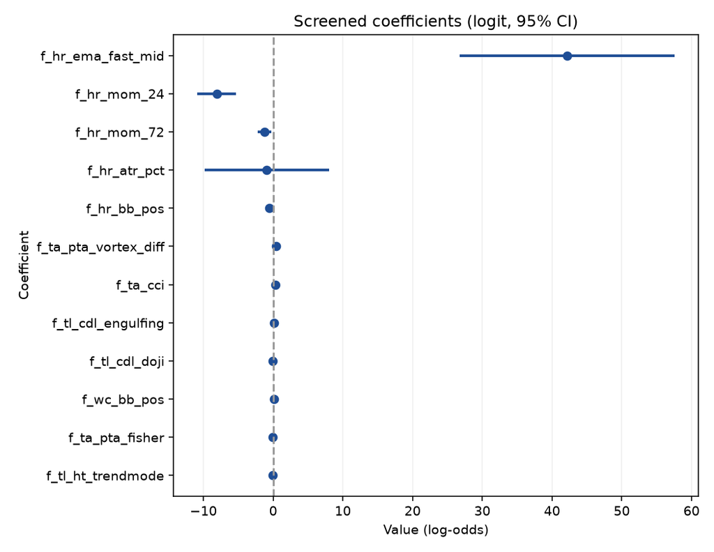

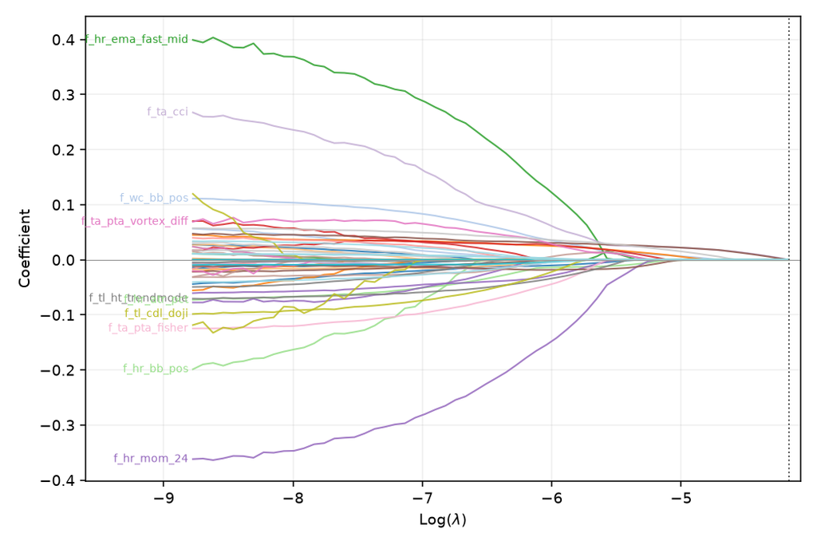

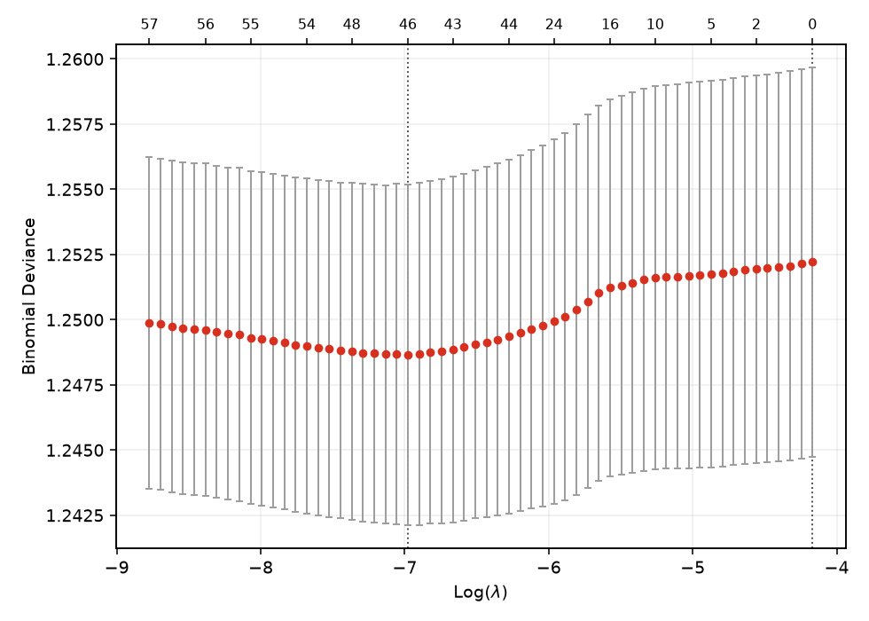

1/7

Each predictor alone, by likelihood ratio

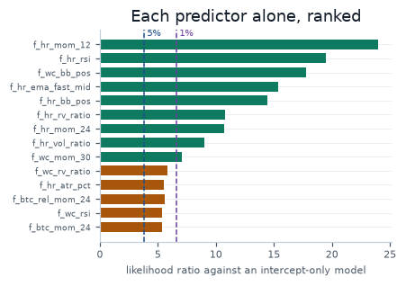

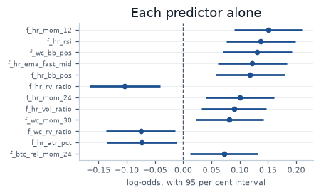

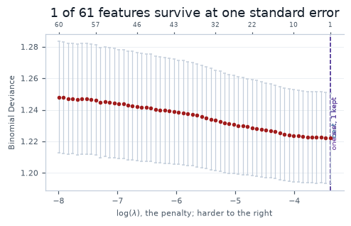

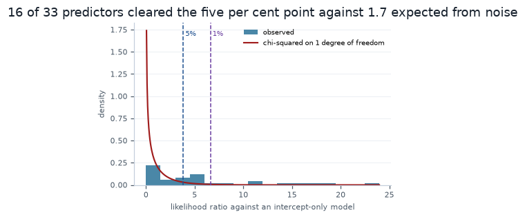

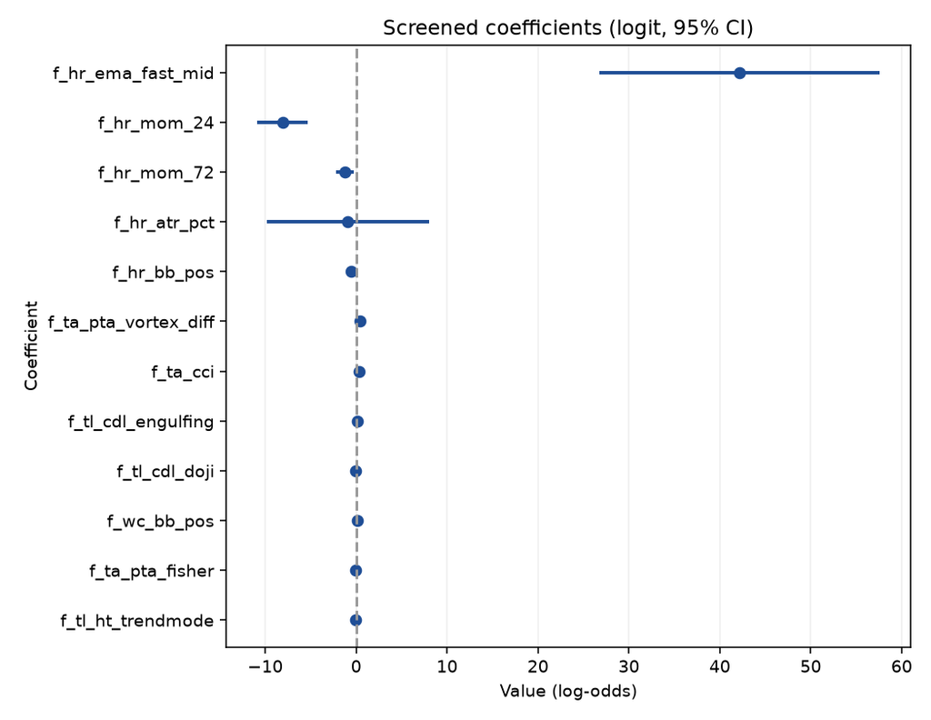

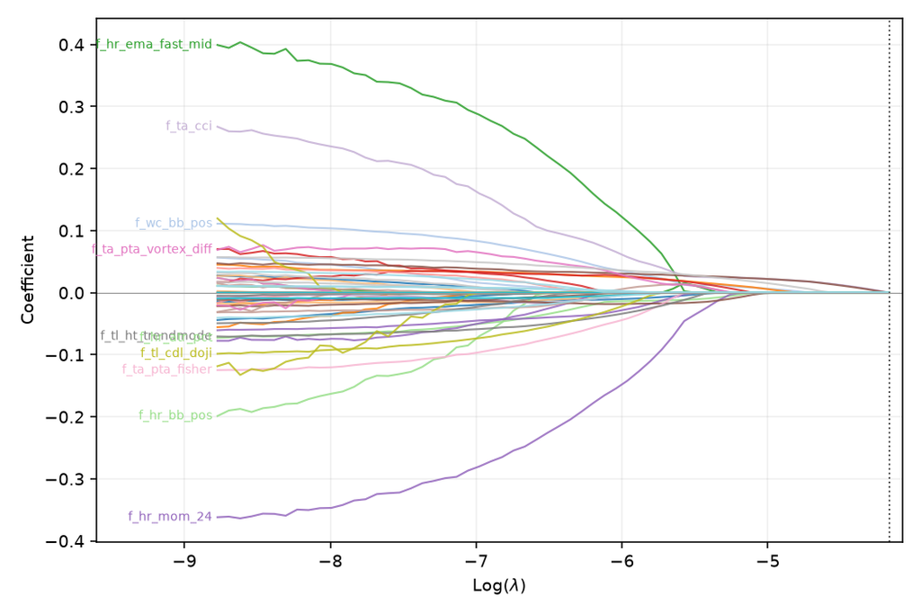

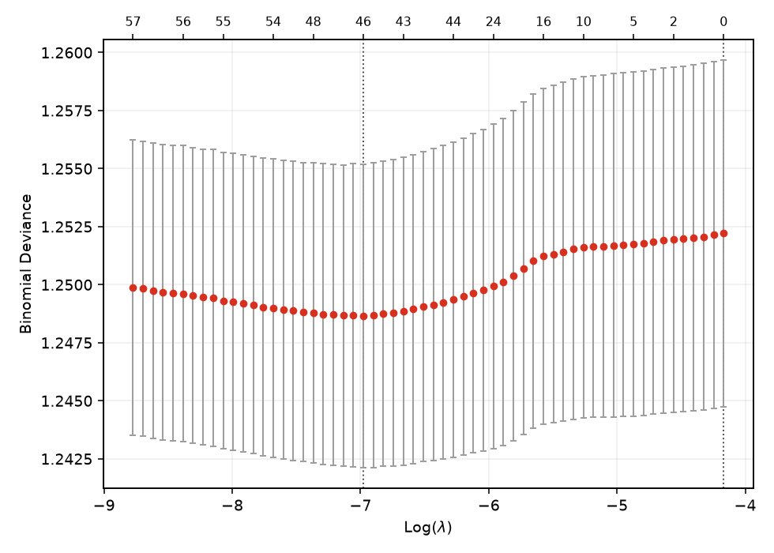

3/7

The elastic-net cross-validation curve

Univariate screen, elastic net, survivors.

22 Sep 2026 4 charts · settings

## B2Trainingblind period, resampling

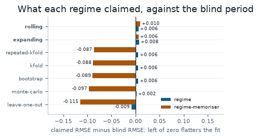

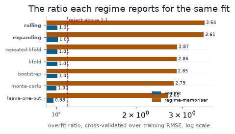

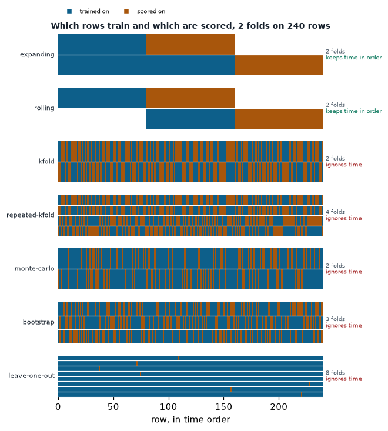

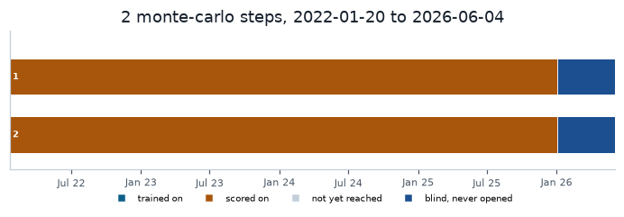

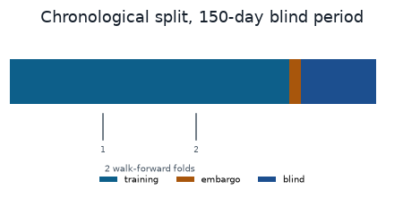

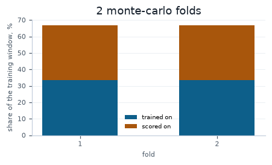

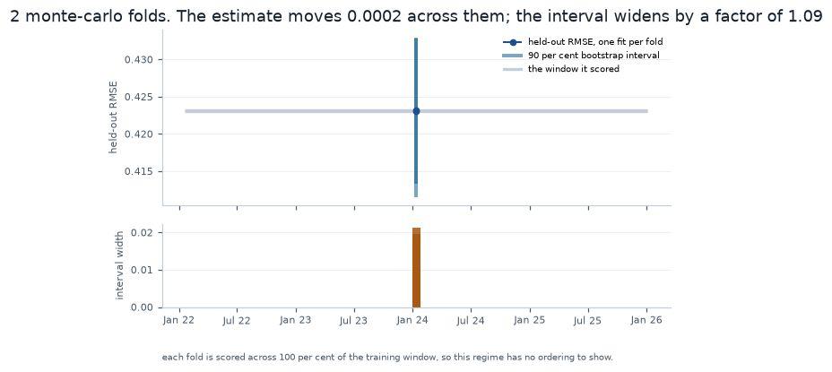

1/7

What each regime claimed, against the blind period

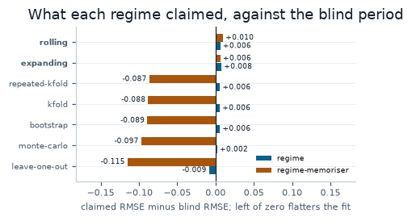

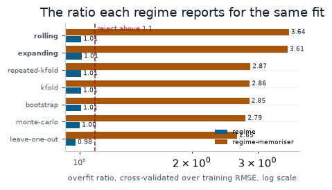

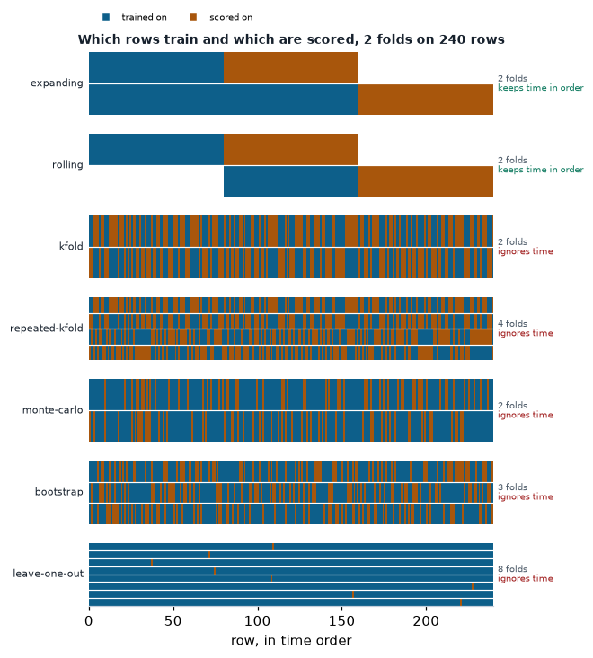

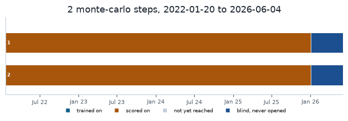

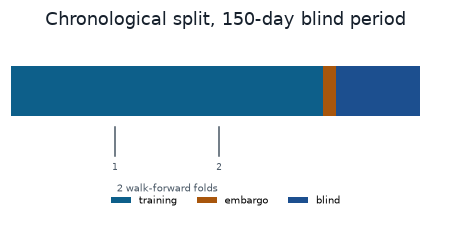

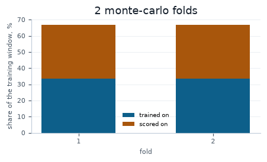

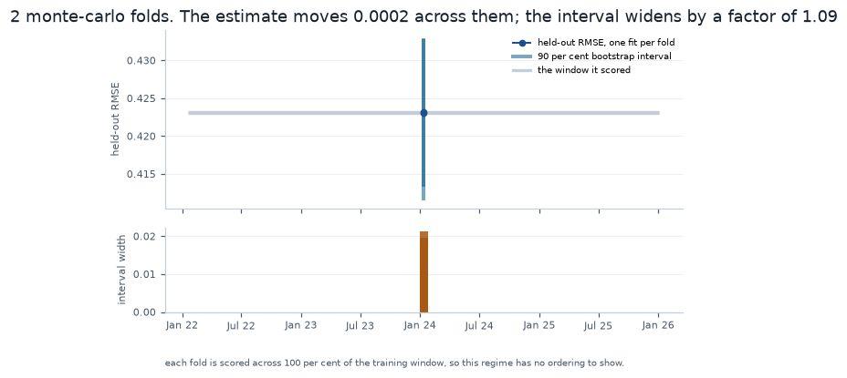

5/7

The chronological split, to scale

Blind period, embargo, folds, regime.

22 Sep 2026 7 charts · settings